# R Notebook

Reference article: https://www.frontiersin.org/journals/psychology/articles/10.3389/fpsyg.2018.01742/full

```r
library(dplyr)
library(qgraph)
library(smacof)
library(ggplot2)
library(tidyr)
```

```r
df <- read.csv('../data/data_cleaned.csv')[2:215]
colnames(df)
```

```
  [1] "ResponseId"        "Gender"            "Province"          "Civil_Status"      "Age"
  [6] "Education_Level"   "Employment_Status" "SES"               "bfi2_01"           "bfi2_02"
 [11] "bfi2_03"           "bfi2_04"           "bfi2_05"           "bfi2_06"           "bfi2_07"
 [16] "bfi2_08"           "bfi2_09"           "bfi2_10"           "bfi2_11"           "bfi2_12"
 [21] "bfi2_13"           "bfi2_14"           "bfi2_15"           "hexaco_01"         "hexaco_02"
 [26] "hexaco_03"         "hexaco_04"         "hexaco_05"         "hexaco_06"         "hexaco_07"
 [31] "hexaco_08"         "hexaco_09"         "hexaco_10"         "cesd_01"           "cesd_02"
 [36] "cesd_03"           "cesd_04"           "cesd_05"           "cesd_06"           "cesd_07"
 [41] "cesd_08"           "cesd_09"           "cesd_10"           "cesd_11"           "cesd_12"
 [46] "cesd_13"           "cesd_14"           "cesd_15"           "cesd_16"           "cesd_17"
 [51] "cesd_18"           "cesd_19"           "cesd_20"           "phq_01"            "phq_02"
 [56] "phq_03"            "phq_04"            "phq_05"            "phq_06"            "phq_07"
 [61] "phq_08"            "phq_09"            "phq_10"            "promis_01"         "promis_02"
 [66] "promis_03"         "promis_04"         "promis_05"         "promis_06"         "promis_07"
 [71] "promis_08"         "promis_09"         "promis_10"         "promis_11"         "promis_12"
```

[output cut: 28 more lines]

```r
phq <- df[ , 54:62]

# no NA in phq
sum(is.na(phq))
```

```
[1] 0
```

```r
phq
```

| phq_01 | phq_02 | phq_03 | phq_04 | phq_05 | phq_06 | phq_07 | phq_08 | phq_09 |
| --- | --- | --- | --- | --- | --- | --- | --- | --- |
| 1 | 2 | 2 | 1 | 2 | 2 | 1 | 2 | 2 |
| 1 | 1 | 1 | 1 | 3 | 3 | 3 | 0 | 1 |
| 0 | 0 | 0 | 1 | 0 | 0 | 0 | 0 | 0 |
| 1 | 1 | 1 | 2 | 1 | 1 | 1 | 1 | 1 |
| 3 | 2 | 2 | 2 | 2 | 2 | 2 | 3 | 2 |
| 1 | 1 | 1 | 1 | 1 | 1 | 1 | 1 | 1 |
| 0 | 1 | 1 | 1 | 0 | 0 | 0 | 0 | 0 |
| 0 | 0 | 1 | 1 | 1 | 0 | 0 | 0 | 0 |
| 0 | 0 | 0 | 0 | 0 | 0 | 0 | 0 | 0 |
| 0 | 0 | 0 | 0 | 0 | 0 | 0 | 0 | 0 |

[output cut: 852 more lines]

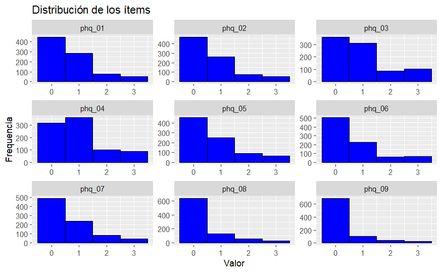

```r
long <- gather(phq, key = "Item", value = "Valor", phq_01:phq_09)

ggplot(long, aes(x=Valor)) + geom_histogram(binwidth = 1, fill="blue", color = "black") +
  facet_wrap(~ Item, scales = "free") +
  labs(title = "Distribución de los ítems", x = "Valor", y = "Frequencia")
```

```r
phq$phq_sum <- phq$phq_01 + phq$phq_02 + phq$phq_03 + phq$phq_04 + phq$phq_05 + phq$phq_06 + phq$phq_07 + phq$phq_08 + phq$phq_09


head(phq)
```

|  | phq_01 | phq_02 | phq_03 | phq_04 | phq_05 | phq_06 | phq_07 | phq_08 | phq_09 | phq_sum |
| --- | --- | --- | --- | --- | --- | --- | --- | --- | --- | --- |
| 1 | 1 | 2 | 2 | 1 | 2 | 2 | 1 | 2 | 2 | 15 |
| 2 | 1 | 1 | 1 | 1 | 3 | 3 | 3 | 0 | 1 | 14 |
| 3 | 0 | 0 | 0 | 1 | 0 | 0 | 0 | 0 | 0 | 1 |
| 4 | 1 | 1 | 1 | 2 | 1 | 1 | 1 | 1 | 1 | 10 |
| 5 | 3 | 2 | 2 | 2 | 2 | 2 | 2 | 3 | 2 | 20 |
| 6 | 1 | 1 | 1 | 1 | 1 | 1 | 1 | 1 | 1 | 9 |

```r
NA
```

```r
summary(phq$phq_sum_1_4)
```

```
Length  Class   Mode
     0   NULL   NULL
```

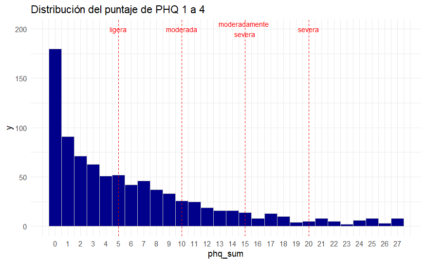

```r
brk <- seq(min(phq$phq_sum),max(phq$phq_sum), by=1)

ggplot(phq, aes(x= phq_sum)) + geom_histogram(binwidth = 1, fill="darkblue", color="grey") + theme_minimal() +
  scale_x_continuous(breaks = brk) + labs(title = "Distribución del puntaje de PHQ 1 a 4") + geom_vline(xintercept =  c(5,10,15,20), color="red", linetype="dashed") + annotate("text", x=  c(5,10,15,20), y= 200,  label = c("ligera", "moderada", "moderadamente \nsevera", "severa"), size=3, color="red")
```

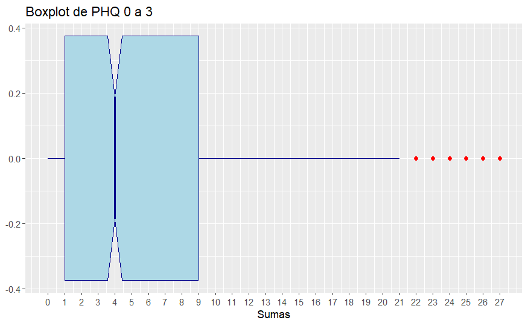

```r
ggplot(phq, aes(phq_sum)) + geom_boxplot(color="darkblue",fill="lightblue",  outlier.colour = "red", notch = TRUE, show.legend = TRUE) +
  scale_x_continuous(breaks = brk) + labs(title = "Boxplot de PHQ 0 a 3", x="Sumas")
```

```r
#count(phq$phq_sum_1_4[phq$phq_sum_1_4 ])
```

### 32 outliers

```r
IQR <- quantile(phq$phq_sum, 0.75) - quantile(phq$phq_sum, 0.25)
outsup <- (IQR * 1.5) + quantile(phq$phq_sum, 0.75)
outinf <- (IQR * 1.5) - quantile(phq$phq_sum, 0.25)


table(phq$phq_sum[phq$phq_sum %in% boxplot.stats(phq$phq_sum)$out] )
```

```
22 23 24 25 26 27
 5  2  6  8  3  8
```

```r
outliers::outlier(phq$phq_01)
```

```
[1] 3
```

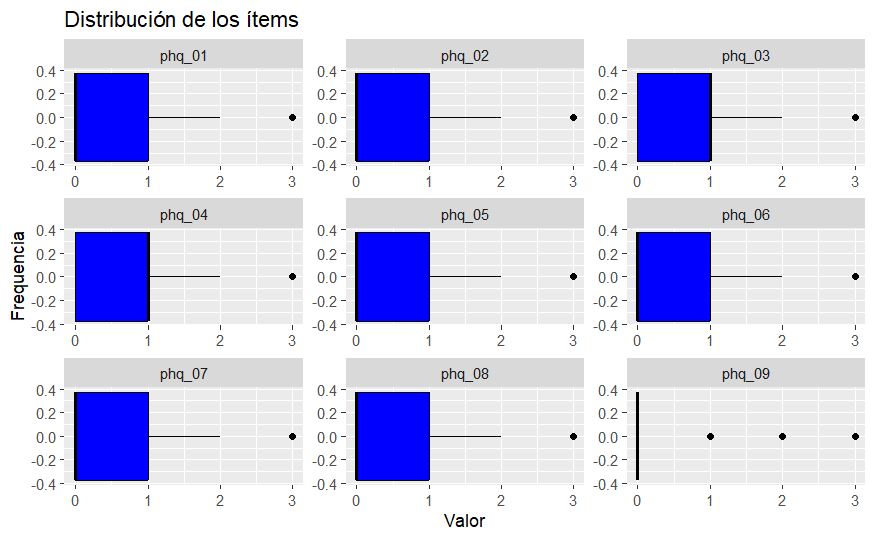

```r
ggplot(long, aes(x=Valor)) + geom_boxplot(fill="blue", color = "black") +
  facet_wrap(~ Item, scales = "free") +
  labs(title = "Distribución de los ítems", x = "Valor", y = "Frequencia")
```

# Force-directed plotting with Fruchterman–Reingold

Most studies on networks in psychopathology have used the Fruchterman-Reingold (FR) algorithm to create graphs. This algorithm, similar to methods by Kamada and Kawai, is like setting up a system of balls connected by stretchy strings. The strings pull connected balls closer, while the other balls push them apart, resulting in a neat graph where nodes are well-spaced and edges are evenly distributed.

Force-directed algorithms aim to produce visually pleasing graphs by minimizing edge crossings and spacing nodes evenly. The goal is not to place the nodes in specific meaningful locations, but to make the network easy to view, showing connections and clusters clearly.

It’s important to avoid interpreting the spatial positions of nodes in these graphs, as the placement is not meant to convey specific meanings. Misinterpreting the layout is a common mistake, as it’s natural to want to find meaning in the arrangement.

The FR algorithm is the default in the qgraph R package, making it straightforward to use.

### Empezamos por crear una correlación de orden cero y a partir de ahí hacer los edges

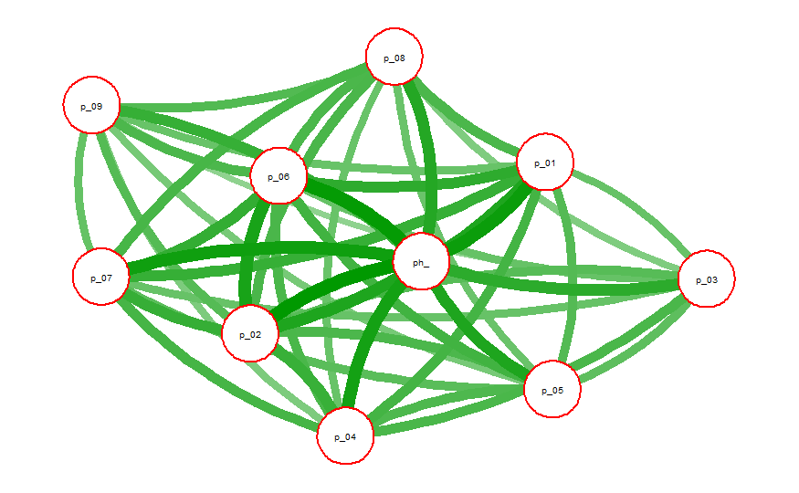

```r
zeroorder_phq <- cor(phq[1:10])

qg_phq <- qgraph(zeroorder_phq, layout = "spring", label.prop=0.4, edge.width = 0.8,curve = 0.7, curveAll = T,  border.color = "red",border.width = 2, directed = FALSE, edge.labels = F, esize = 18)
```

### Dividing by gender

```r
sum(is.na(df$Gender))
```

```
[1] 0
```

```r
phq$gender <- df$Gender

phq_gndr <- phq %>%
  select(gender, phq_01, phq_02,phq_03,phq_04,phq_05,phq_06,phq_07,phq_08,phq_09, phq_sum)

phq_gndr_M <- phq_gndr %>%
  filter(gender == 1)

phq_gndr_F <- phq_gndr %>%
  filter(gender == 2)

zeroorder_phq_M <- cor(phq_gndr_M[2:length(phq_gndr_M)])
zeroorder_phq_F <- cor(phq_gndr_F[2:length(phq_gndr_F)])
```

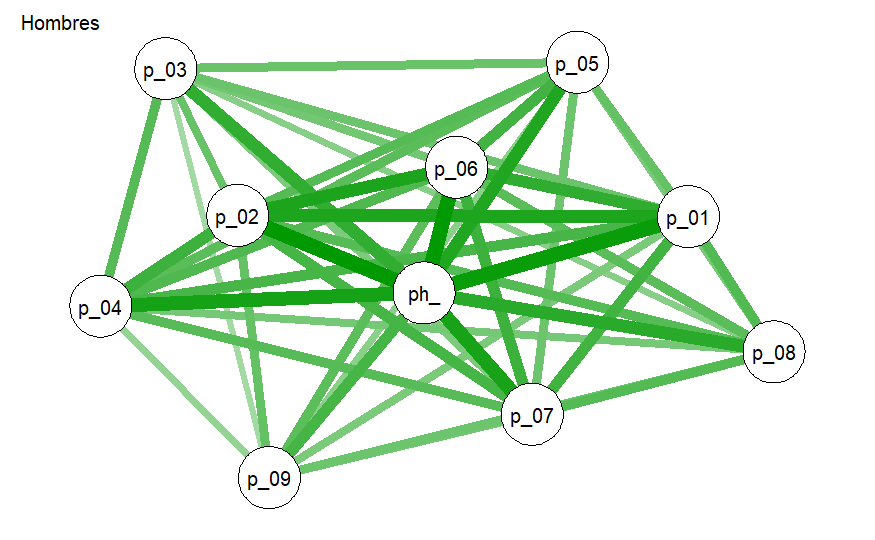

```r
qg_phq_M <- qgraph(zeroorder_phq_M, layout = "spring", title= "Hombres")
```

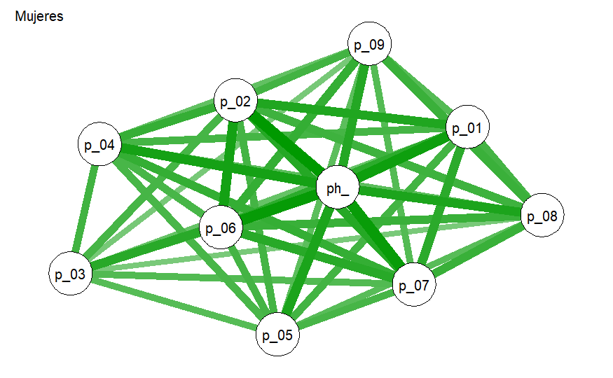

```r
qg_phq_F <- qgraph(zeroorder_phq_F, layout = "spring", title ="Mujeres")
```

```r
#FR_net_by_scales_topnum_measures(phq, list(phq), 10)

phq_centrality <- as.data.frame(centrality(qg_phq))

phq_centrality %>%
  arrange(desc(OutDegree))
```

|  | OutDegree | InDegree | Closeness | Betweenness | InExpectedInfluence | OutExpectedInfluence | ShortestPathLengths.p_01 | ShortestPathLengths.p_02 | ShortestPathLengths.p_03 | ShortestPathLengths.p_04 | ShortestPathLengths.p_05 | ShortestPathLengths.p_06 | ShortestPathLengths.p_07 | ShortestPathLengths.p_08 | ShortestPathLengths.p_09 | ShortestPathLengths.ph_ | ShortestPaths.p_01 | ShortestPaths.p_02 | ShortestPaths.p_03 | ShortestPaths.p_04 | ShortestPaths.p_05 | ShortestPaths.p_06 | ShortestPaths.p_07 | ShortestPaths.p_08 | ShortestPaths.p_09 | ShortestPaths.ph_ |
| --- | --- | --- | --- | --- | --- | --- | --- | --- | --- | --- | --- | --- | --- | --- | --- | --- | --- | --- | --- | --- | --- | --- | --- | --- | --- | --- |
| ph_ | 7.223964 | 7.223964 | 0.08866796 | 0 | 7.223964 | 7.223964 | 1.180079 | 1.129804 | 1.364745 | 1.227516 | 1.277702 | 1.147921 | 1.202228 | 1.312810 | 1.435225 | 0.000000 |  |  |  |  |  |  |  |  |  |  |
| p_02 | 6.279192 | 6.279192 | 0.07606015 | 0 | 6.279192 | 6.279192 | 1.280009 | 0.000000 | 1.716651 | 1.450798 | 1.610568 | 1.249511 | 1.431099 | 1.588313 | 1.690736 | 1.129804 |  |  |  |  |  |  |  |  |  |  |
| p_06 | 6.171697 | 6.171697 | 0.07471017 | 0 | 6.171697 | 6.171697 | 1.377718 | 1.249511 | 1.881231 | 1.591410 | 1.515764 | 0.000000 | 1.410094 | 1.603983 | 1.607427 | 1.147921 |  |  |  |  |  |  |  |  |  |  |
| p_01 | 5.973794 | 5.973794 | 0.07197708 | 0 | 5.973794 | 5.973794 | 0.000000 | 1.280009 | 1.889330 | 1.544012 | 1.682158 | 1.377718 | 1.431817 | 1.596470 | 1.911718 | 1.180079 |  |  |  |  |  |  |  |  |  |  |
| p_07 | 5.853244 | 5.853244 | 0.07085846 | 0 | 5.853244 | 5.853244 | 1.431817 | 1.431099 | 1.894659 | 1.555863 | 1.742754 | 1.410094 | 0.000000 | 1.567974 | 1.876152 | 1.202228 |  |  |  |  |  |  |  |  |  |  |
| p_04 | 5.639130 | 5.639130 | 0.06794703 | 0 | 5.639130 | 5.639130 | 1.544012 | 1.450798 | 1.590152 | 0.000000 | 1.631538 | 1.591410 | 1.555863 | 1.912401 | 2.213656 | 1.227516 |  |  |  |  |  |  |  |  |  |  |
| p_05 | 5.393200 | 5.393200 | 0.06535621 | 0 | 5.393200 | 5.393200 | 1.682158 | 1.610568 | 1.785031 | 1.631538 | 0.000000 | 1.515764 | 1.742754 | 1.933606 | 2.121642 | 1.277702 |  |  |  |  |  |  |  |  |  |  |
| p_08 | 5.360943 | 5.360943 | 0.06475415 | 0 | 5.360943 | 5.360943 | 1.596470 | 1.588313 | 2.258549 | 1.912401 | 1.933606 | 1.603983 | 1.567974 | 0.000000 | 1.668919 | 1.312810 |  |  |  |  |  |  |  |  |  |  |
| p_03 | 4.924972 | 4.924972 | 0.05899810 | 0 | 4.924972 | 4.924972 | 1.889330 | 1.716651 | 0.000000 | 1.590152 | 1.785031 | 1.881231 | 1.894659 | 2.258549 | 2.569349 | 1.364745 |  |  |  |  |  |  |  |  |  |  |
| p_09 | 4.877889 | 4.877889 | 0.05849724 | 0 | 4.877889 | 4.877889 | 1.911718 | 1.690736 | 2.569349 | 2.213656 | 2.121642 | 1.607427 | 1.876152 | 1.668919 | 0.000000 | 1.435225 |  |  |  |  |  |  |  |  |  |  |

```r
centrality_auto(qg_phq)
```

```
$node.centrality
     Betweenness  Closeness Strength ExpectedInfluence
p_01           0 0.07197708 5.973794          5.973794
p_02           0 0.07606015 6.279192          6.279192
p_03           0 0.05899810 4.924972          4.924972
p_04           0 0.06794703 5.639130          5.639130
p_05           0 0.06535621 5.393200          5.393200
p_06           0 0.07471017 6.171697          6.171697
p_07           0 0.07085846 5.853244          5.853244
p_08           0 0.06475415 5.360943          5.360943
p_09           0 0.05849724 4.877889          4.877889
ph_            0 0.08866796 7.223964          7.223964

$edge.betweenness.centrality
   from   to edgebetweenness
1  p_01 p_02               1
2  p_02 p_03               1
3  p_02 p_04               1
4  p_02 p_05               1
5  p_02 p_06               1
6  p_02 p_07               1
7  p_02 p_08               1
8  p_02 p_09               1
9  p_02  ph_               1
10 p_03 p_04               1
11 p_03 p_05               1
12 p_01 p_03               1
13 p_03 p_06               1
14 p_03 p_07               1
15 p_03 p_08               1
16 p_03 p_09               1
17 p_03  ph_               1
18 p_04 p_05               1
19 p_04 p_06               1
20 p_04 p_07               1
21 p_04 p_08               1
22 p_04 p_09               1
23 p_01 p_04               1
24 p_04  ph_               1
25 p_05 p_06               1
```

[output cut: 21 more lines]

```
$ShortestPathLengths
         p_01     p_02     p_03     p_04     p_05     p_06     p_07     p_08     p_09      ph_
p_01 0.000000 1.280009 1.889330 1.544012 1.682158 1.377718 1.431817 1.596470 1.911718 1.180079
p_02 1.280009 0.000000 1.716651 1.450798 1.610568 1.249511 1.431099 1.588313 1.690736 1.129804
p_03 1.889330 1.716651 0.000000 1.590152 1.785031 1.881231 1.894659 2.258549 2.569349 1.364745
p_04 1.544012 1.450798 1.590152 0.000000 1.631538 1.591410 1.555863 1.912401 2.213656 1.227516
p_05 1.682158 1.610568 1.785031 1.631538 0.000000 1.515764 1.742754 1.933606 2.121642 1.277702
p_06 1.377718 1.249511 1.881231 1.591410 1.515764 0.000000 1.410094 1.603983 1.607427 1.147921
p_07 1.431817 1.431099 1.894659 1.555863 1.742754 1.410094 0.000000 1.567974 1.876152 1.202228
p_08 1.596470 1.588313 2.258549 1.912401 1.933606 1.603983 1.567974 0.000000 1.668919 1.312810
p_09 1.911718 1.690736 2.569349 2.213656 2.121642 1.607427 1.876152 1.668919 0.000000 1.435225
ph_  1.180079 1.129804 1.364745 1.227516 1.277702 1.147921 1.202228 1.312810 1.435225 0.000000

attr(,"class")
[1] "list"            "centrality_auto"
```

# Checking almost all variables

```r
df_gen <- df %>%
  select(!c(Gender, Civil_Status, Employment_Status, Province, ResponseId))

gen_zeroorder <- cor(df_gen, use = "complete.obs")

colnames(df_gen)
```

```
  [1] "Age"             "Education_Level" "SES"             "bfi2_01"         "bfi2_02"         "bfi2_03"
  [7] "bfi2_04"         "bfi2_05"         "bfi2_06"         "bfi2_07"         "bfi2_08"         "bfi2_09"
 [13] "bfi2_10"         "bfi2_11"         "bfi2_12"         "bfi2_13"         "bfi2_14"         "bfi2_15"
 [19] "hexaco_01"       "hexaco_02"       "hexaco_03"       "hexaco_04"       "hexaco_05"       "hexaco_06"
 [25] "hexaco_07"       "hexaco_08"       "hexaco_09"       "hexaco_10"       "cesd_01"         "cesd_02"
 [31] "cesd_03"         "cesd_04"         "cesd_05"         "cesd_06"         "cesd_07"         "cesd_08"
 [37] "cesd_09"         "cesd_10"         "cesd_11"         "cesd_12"         "cesd_13"         "cesd_14"
 [43] "cesd_15"         "cesd_16"         "cesd_17"         "cesd_18"         "cesd_19"         "cesd_20"
 [49] "phq_01"          "phq_02"          "phq_03"          "phq_04"          "phq_05"          "phq_06"
 [55] "phq_07"          "phq_08"          "phq_09"          "phq_10"          "promis_01"       "promis_02"
 [61] "promis_03"       "promis_04"       "promis_05"       "promis_06"       "promis_07"       "promis_08"
 [67] "promis_09"       "promis_10"       "promis_11"       "promis_12"       "promis_13"       "promis_14"
 [73] "promis_15"       "promis_16"       "promis_17"       "promis_18"       "promis_19"       "promis_20"
 [79] "promis_21"       "promis_22"       "promis_23"       "promis_24"       "promis_25"       "promis_26"
 [85] "promis_27"       "promis_28"       "qids_01"         "qids_02"         "qids_03"         "qids_04"
```

[output cut: 20 more lines]

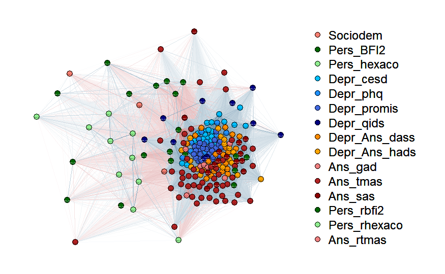

```r
groups <- list(Sociodem = 1:3, Pers_BFI2 = 4:18, Pers_hexaco = 19:28, Depr_cesd = 29:48, Depr_phq = 49:58, Depr_promis = 59:85, Depr_qids = 86:95, Depr_Ans_dass = 96:115, Depr_Ans_hads = 116:133, Ans_gad = 134:140, Ans_tmas = 141:190, Ans_sas = 191:205, Pers_rbfi2 = 206:209, Pers_rhexaco = 210:217, Ans_rtmas = 218:229)

color_nodes <- c("salmon", "darkgreen", "lightgreen", "deepskyblue", "dodgerblue", "royalblue", "navy", "darkorange", "orange", "lightcoral", "firebrick", "darkred",  "darkgreen", "lightgreen" ,"lightcoral")


qg <- qgraph(gen_zeroorder, layout="spring", labels = colnames(gen_zeroorder), groups = groups , color = color_nodes, theme="TeamFortress", height = 180, width = 140)
```

```r
qg
```

[output not shown]

[output cut: 2715 more lines]

## Multidimensional Scaling of Networks

MDS represents proximities among variables as distances between points in a low-dimensional space (e.g., two or three dimensions; Mair et al., 2016). Proximity is an umbrella term for “similarities” between variables (e.g., correlation) or “dissimilarities” (e.g., Euclidean distance). Because MDS helps represent complex data in low-dimensional space, it dovetails precisely with the goal of visual presentation of complex psychological networks. That is, we can use MDS to represent proximities in a two-dimensional space (e.g., X & Y) to produce two-dimensional network plots. MDS is particularly useful for understanding networks because the distances between plotted nodes are interpretable as Euclidean distances.

Because the smacof R package (De Leeuw and Mair, 2009) requires dissimilarities (rather than similarities) as input, we will convert the correlation matrix into a dissimilarity matrix.

```r
library("smacof")

dissimilarities <- sim2diss(gen_zeroorder)

head(round(dissimilarities$conf, 2))
```

[output not shown]

After determining our dissimilarity matrix, we then locate points (configuration matrix) in a two-dimensional space such that the distances between the objects (nodes) approximate a transformation of the dissimilarities as closely as possible, given the constraints of a two-dimensional solution.

```r
MDS <- mds(dissimilarities)
```

## Transformations

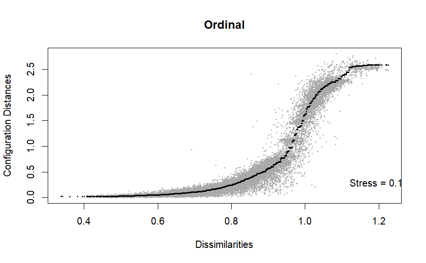

```r
MDS_ordinal <- mds(dissimilarities, type = 'ordinal')
plot(MDS_ordinal, plot.type = "Shepard", main = "Ordinal")
text(1.2,0.3, paste("Stress =", round(MDS_ordinal$stress,2)))
```

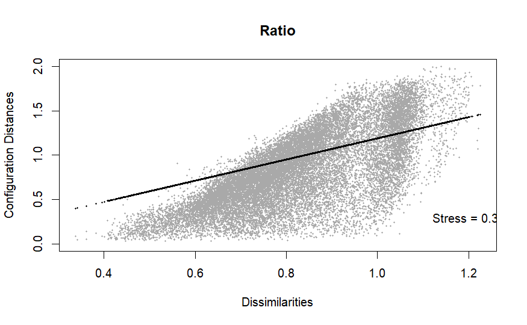

```r
MDS_ratio <- mds(dissimilarities, type = "ratio")
plot(MDS_ratio, plot.type = "Shepard", main = "Ratio")
text(1.2,0.3, paste("Stress =", round(MDS_ratio$stress,2)))
```

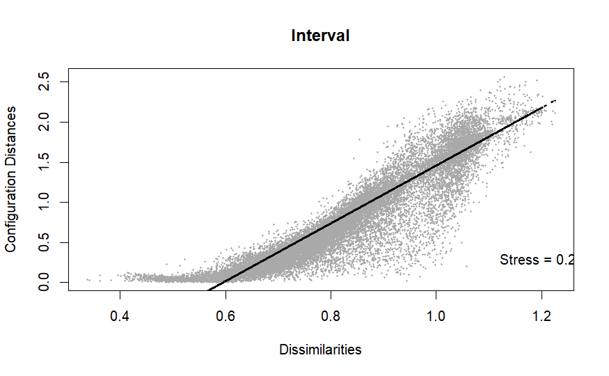

```r
MDS_interval <- mds(dissimilarities, type = "interval")
plot(MDS_interval, plot.type = "Shepard", main = "Interval")
text(1.2,0.3, paste("Stress =", round(MDS_interval$stress,2)))
```

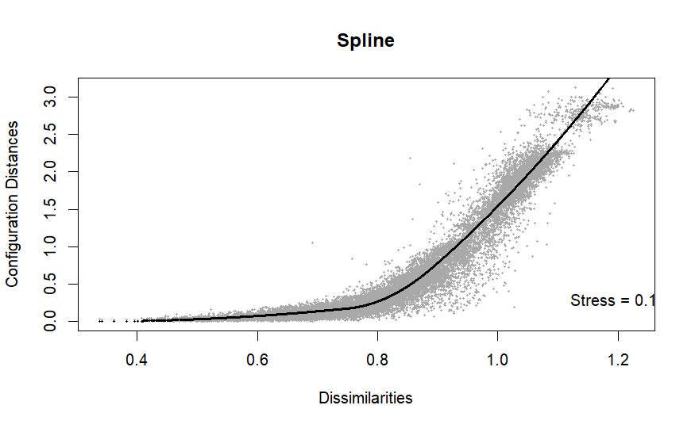

```r
MDS_mspline <- mds(dissimilarities, type = "mspline")
plot(MDS_mspline, plot.type = "Shepard", main = "Spline")
text(1.2,0.3, paste("Stress =", round(MDS_mspline$stress,2)))
```

```r
qgraph(gen_zeroorder, layout = MDS_ordinal$conf, labels = colnames(gen_zeroorder), groups = groups , color = color_nodes, vsize=4)
text(-1,-1, paste("Stress=",round(MDS_ordinal$stress,2)))

qgraph(gen_zeroorder, layout = MDS_mspline$conf, labels = colnames(gen_zeroorder), groups = groups , color = color_nodes)
text(-1,-1, paste("Stress=",round(MDS_mspline$stress,2)))
```

[output not shown]

```r
library("wordcloud")

#qgraph(gen_zeroorder, layout = MDS_ordinal$conf, labels = colnames(gen_zeroorder), groups = groups , color = color_nodes, vsize=0, rescale=FALSE, labels=FALSE)

qgraph(gen_zeroorder, layout = MDS_ordinal$conf, vsize=0, rescale=FALSE, labels=FALSE)

points(MDS_ordinal$conf, pch=16)

textplot(MDS_ordinal$conf[,1]+.03, MDS_ordinal$conf[,2]+.03, colnames(gen_zeroorder), new=F)



#text(-1,-1, paste("Stress=",round(MDS_ordinal$stress,2)))
```

[output not shown]

```r
df_gen <- df_gen %>% na.omit(df_gen)
lasso <- EBICglasso(cor(phq),  dim(phq)[1])

qgraph(lasso, layout = MDS_ordinal, vsize=4)
```

[output not shown]

```r
cleaned_phq <- phq %>% na.omit(phq)
cor(cleaned_phq)
l <- EBICglasso(cor(cleaned_phq), dim(cleaned_phq)[1])

qgraph(l, layout = "sprin", vsize=4)
```

```r
dim(phq)
phq[1:10]
```

```r
centrality(qg, alpha = 1, posfun = abs, all.shortest.paths = FALSE,
weighted = TRUE, signed = TRUE, R2 = FALSE)

centralityPlot(qg)
```

[output not shown]

```r
library(psych)
data(bfi)
```

```r
# Compute correlations:
CorMat <- cor_auto(bfi[,1:25])
# Compute graph with tuning = 0 (BIC):
BICgraph <- EBICglasso(CorMat, nrow(bfi), 0, threshold = TRUE)
# Compute graph with tuning = 0.5 (EBIC)
EBICgraph <- EBICglasso(CorMat, nrow(bfi), 0.5, threshold = TRUE)

# Plot both:
layout(t(1:2))
BICgraph <- qgraph(BICgraph, layout = "spring", title = "BIC", details = TRUE)
EBICgraph <- qgraph(EBICgraph, layout = "spring", title = "EBIC")
# Compare centrality and clustering:
layout(1)
centralityPlot(list(BIC = BICgraph, EBIC = EBICgraph))
clusteringPlot(list(BIC = BICgraph, EBIC = EBICgraph))
```

```r
zeroorder_phq <- cor_auto(phq[,1:10])
zeroorder_phq


# Compute graph with tuning = 0 (BIC):
BICgraph <- EBICglasso(zeroorder_phq, nrow(phq[1:10]), 0, threshold = TRUE)
# Compute graph with tuning = 0.5 (EBIC)
EBICgraph <- EBICglasso(zeroorder_phq, nrow(phq[1:10]), 0.5, threshold = TRUE)

# Plot both:
layout(t(1:2))
BICgraph <- qgraph(BICgraph, layout = "spring", title = "BIC", details = TRUE)
EBICgraph <- qgraph(EBICgraph, layout = "spring", title = "EBIC")
# Compare centrality and clustering:
layout(1)
centralityPlot(list(BIC = BICgraph, EBIC = EBICgraph))
clusteringPlot(list(BIC = BICgraph, EBIC = EBICgraph))
```

```r
df <- read.csv('data/data/data_cleaned.csv')
```

```r
install.packages("RSQLite")
library(RSQLite)
```

```r
conn <- dbConnect(RSQLite::SQLite(), "mm.db")

dbWriteTable(conn, 'mmdep', df)

dbListTables(conn)
```

```r
dbGetQuery(conn, "select * from mmdep")
```

```r
FR_net_by_scales_topnum_measures <- function(df, list_cols, top_number) # list_cols may have format: names = range (e.g.: cesd = 35:54)
{
  #unlisting cols to subset them
  vec_cols <- unlist(list_cols)

  ndf <- df[vec_cols]

  #creating correlation
  cor_mat <- cor(ndf)
  # creating indices to group by name



    update_indices <- function(indices, offset) {
    return(seq(from = 1 + offset, to = length(indices) + offset))
  }

  # Calculate the offset
  offset <- 0

  # Create the updated list of ranges
  updated_list_cols <- list()
  for (name in names(list_cols)) {
    updated_list_cols[[name]] <- update_indices(list_cols[[name]], offset)
    offset <- offset + length(list_cols[[name]])}


  # creating network
qg <- qgraph(cor_mat, layout="spring", labels = colnames(cor_mat), groups = updated_list_cols ,color = sample(colors(), length(list_cols)), title = "Network of all items selected")


cent_net <- as.data.frame(centrality(qg))

# By degree
cent_net_degree <- cent_net%>%
  arrange(desc(OutDegree))
cent_net_degree <- cent_net_degree[1:top_number, ]

# By betweenness
cent_net_bet <- cent_net%>%
arrange(desc(Betweenness))
cent_net_bet <- cent_net_bet[1:top_number, ]

# By closeness
cent_net_clos <- cent_net%>%
arrange(desc(Closeness))
cent_net_clos <- cent_net_clos[1:top_number, ]



# Subsetting the top variables
cut_df_degree <- df[row.names(cent_net_degree)]
cor_cut_df_degree <- cor(cut_df_degree)

cut_df_bet <- df[row.names(cent_net_bet)]
cor_cut_df_bet <- cor(cut_df_bet)

cut_df_clos <- df[row.names(cent_net_clos)]
cor_cut_df_clos <- cor(cut_df_clos)

sel_measure_degree <- qgraph(cor_cut_df_degree, layout = "spring", labels = colnames(cor_cut_df_degree), theme="TeamFortress", title = paste("Network of the top", top_number, "nodes with the highest Degree"))

sel_measure_bet <- qgraph(cor_cut_df_bet, layout = "spring", labels = colnames(cor_cut_df_bet), theme="TeamFortress", title = paste("Network of the top", top_number, "nodes with the highest Betweenness"))

sel_measure_clos <- qgraph(cor_cut_df_clos, layout = "spring", labels = colnames(cor_cut_df_clos), theme="TeamFortress", title = paste("Network of the top", top_number, "nodes with the highest Closeness"))


  return(list(df = ndf, network =  qg, selected_bet = sel_measure_bet,selected_clos = sel_measure_clos, measures = cent_net, selected_degree = cent_net_degree, selected_betweenness = cent_net_bet, selected_closeness = cent_net_clos))
}
```